# Tikslai

# BVP per capita duomenų paruošimas

https://data.worldbank.org/indicator/NY.GDP.PCAP.PP.CD

```python
gdp = pd.read_csv('Gdp_per_capita.csv')
gdp
```

|  | Data Source | World Development Indicators | Unnamed: 2 | Unnamed: 3 | Unnamed: 4 | Unnamed: 5 | Unnamed: 6 | Unnamed: 7 | Unnamed: 8 | Unnamed: 9 | ... | Unnamed: 55 | Unnamed: 56 | Unnamed: 57 | Unnamed: 58 | Unnamed: 59 | Unnamed: 60 | Unnamed: 61 | Unnamed: 62 | Unnamed: 63 | Unnamed: 64 |
| --- | --- | --- | --- | --- | --- | --- | --- | --- | --- | --- | --- | --- | --- | --- | --- | --- | --- | --- | --- | --- | --- |
| 0 | NaN | NaN | NaN | NaN | NaN | NaN | NaN | NaN | NaN | NaN | ... | NaN | NaN | NaN | NaN | NaN | NaN | NaN | NaN | NaN | NaN |
| 1 | Last Updated Date | 15/02/2022 | NaN | NaN | NaN | NaN | NaN | NaN | NaN | NaN | ... | NaN | NaN | NaN | NaN | NaN | NaN | NaN | NaN | NaN | NaN |
| 2 | NaN | NaN | NaN | NaN | NaN | NaN | NaN | NaN | NaN | NaN | ... | NaN | NaN | NaN | NaN | NaN | NaN | NaN | NaN | NaN | NaN |
| 3 | Country Name | Country Code | Indicator Name | Indicator Code | 1960.0 | 1961.0 | 1962.0 | 1963.0 | 1964.0 | 1965.0 | ... | 2011.000000 | 2012.000000 | 2013.000000 | 2014.000000 | 2015.000000 | 2016.000000 | 2017.000000 | 2018.000000 | 2019.000000 | 2020.000000 |
| 4 | Aruba | ABW | GDP per capita, PPP (current international $) | NY.GDP.PCAP.PP.CD | NaN | NaN | NaN | NaN | NaN | NaN | ... | 34324.799360 | 33567.550020 | 36829.032770 | 36779.429430 | 37311.750320 | 37585.025080 | 38897.122670 | NaN | NaN | NaN |
| ... | ... | ... | ... | ... | ... | ... | ... | ... | ... | ... | ... | ... | ... | ... | ... | ... | ... | ... | ... | ... | ... |
| 265 | Kosovo | XKX | GDP per capita, PPP (current international $) | NY.GDP.PCAP.PP.CD | NaN | NaN | NaN | NaN | NaN | NaN | ... | 7780.594464 | 8039.207976 | 8383.397311 | 8649.449499 | 9357.135136 | 10007.689230 | 10436.168850 | 11013.397080 | 11797.119320 | 11387.645340 |
| 266 | Yemen, Rep. | YEM | GDP per capita, PPP (current international $) | NY.GDP.PCAP.PP.CD | NaN | NaN | NaN | NaN | NaN | NaN | ... | 3607.090566 | 3491.204610 | 3688.519409 | NaN | NaN | NaN | NaN | NaN | NaN | NaN |
| 267 | South Africa | ZAF | GDP per capita, PPP (current international $) | NY.GDP.PCAP.PP.CD | NaN | NaN | NaN | NaN | NaN | NaN | ... | 13393.766890 | 13215.708680 | 13606.942900 | 13602.102640 | 13701.945390 | 13748.461420 | 13860.270170 | 14209.093830 | 14289.760000 | 13360.574010 |
| 268 | Zambia | ZMB | GDP per capita, PPP (current international $) | NY.GDP.PCAP.PP.CD | NaN | NaN | NaN | NaN | NaN | NaN | ... | 3323.937623 | 3422.619937 | 3578.847055 | 3539.436390 | 3430.400287 | 3404.673990 | 3485.021780 | 3606.097632 | 3617.200014 | 3457.610102 |
| 269 | Zimbabwe | ZWE | GDP per capita, PPP (current international $) | NY.GDP.PCAP.PP.CD | NaN | NaN | NaN | NaN | NaN | NaN | ... | 2101.824051 | 2375.927006 | 2560.773267 | 2612.455954 | 2679.507615 | 2806.469032 | 3795.642431 | 4017.221716 | 3783.547898 | 3537.351394 |

270 rows × 65 columns

```python
gdp.drop(gdp.loc[:, 'Unnamed: 2':'Unnamed: 34'].columns, axis = 1, inplace=True)
```

```python
gdp.drop([gdp.index[0], gdp.index[1], gdp.index[2], gdp.index[3]], inplace=True)
```

```python
gdp.rename(columns={'Data Source': 'Country Name', 'World Development Indicators': 'Country Code', 'Unnamed: 35': '1991',
                    'Unnamed: 36': '1992', 'Unnamed: 37': '1993', 'Unnamed: 38': '1994', 'Unnamed: 39': '1995',
                    'Unnamed: 40': '1996', 'Unnamed: 41': '1997', 'Unnamed: 42': '1998', 'Unnamed: 43': '1999',
                    'Unnamed: 44': '2000', 'Unnamed: 45': '2001', 'Unnamed: 46': '2002', 'Unnamed: 47': '2003',
                    'Unnamed: 48': '2004', 'Unnamed: 49': '2005', 'Unnamed: 50': '2006', 'Unnamed: 51': '2007',
                    'Unnamed: 52': '2008', 'Unnamed: 52': '2008', 'Unnamed: 53': '2009', 'Unnamed: 54': '2010',
                    'Unnamed: 55': '2011', 'Unnamed: 56': '2012', 'Unnamed: 57': '2013', 'Unnamed: 58': '2014',
                    'Unnamed: 59': '2015', 'Unnamed: 60': '2016', 'Unnamed: 61': '2017', 'Unnamed: 62': '2018',
                    'Unnamed: 63': '2019', 'Unnamed: 64': '2020'}, inplace=True)
```

```python
gdp = gdp[gdp['Country Name'].isin(['Lithuania', 'Latvia', 'Estonia','Ukraine', 'Armenia', 'Azerbaijan', 'Georgia', 'Turkmenistan',
                             'Tajikistan', 'Kyrgyz Republic', 'Kazakhstan', 'Uzbekistan', 'Moldova', 'Belarus',
                             'Russian Federation'])]
```

```python
gdp = gdp.fillna(0)
```

```python
gdp.to_csv('gdp_tableu.csv')
```

```python
gdp
```

|  | Country Name | Country Code | 1991 | 1992 | 1993 | 1994 | 1995 | 1996 | 1997 | 1998 | ... | 2011 | 2012 | 2013 | 2014 | 2015 | 2016 | 2017 | 2018 | 2019 | 2020 |
| --- | --- | --- | --- | --- | --- | --- | --- | --- | --- | --- | --- | --- | --- | --- | --- | --- | --- | --- | --- | --- | --- |
| 14 | Armenia | ARM | 2554.373165 | 1548.096243 | 1479.585479 | 1631.321528 | 1817.148263 | 1989.335728 | 2115.617044 | 2313.617793 | ... | 8025.458485 | 9364.375299 | 9835.802461 | 10036.889840 | 9969.664854 | 10704.229760 | 12115.139290 | 13020.396320 | 14231.180190 | 13312.113860 |
| 19 | Azerbaijan | AZE | 5324.280172 | 4151.671993 | 3219.144386 | 2604.809937 | 2318.665985 | 2367.736202 | 2525.380061 | 2782.647228 | ... | 14804.574450 | 15957.718850 | 17188.945510 | 17443.878260 | 14938.401130 | 14371.022740 | 14121.406940 | 14550.762820 | 15052.793870 | 14479.705410 |
| 29 | Belarus | BLR | 5338.054364 | 4924.741099 | 4648.049139 | 4196.827402 | 3851.683478 | 4045.626092 | 4606.522435 | 5072.469255 | ... | 16563.201410 | 18105.286720 | 18994.190190 | 19008.061020 | 18095.665180 | 17785.943200 | 18356.100770 | 19430.278770 | 20094.525810 | 20239.201820 |
| 75 | Estonia | EST | 0.000000 | 0.000000 | 0.000000 | 0.000000 | 6476.327722 | 6889.810061 | 7979.377726 | 8450.577598 | ... | 24557.236150 | 25996.046780 | 27464.518680 | 28945.465330 | 29175.925930 | 31312.752300 | 33821.932910 | 36249.358150 | 37850.074150 | 37600.592050 |
| 86 | Georgia | GEO | 4638.872304 | 2594.098452 | 1863.125857 | 1731.459299 | 1883.179623 | 2211.257563 | 2568.643330 | 2745.296805 | ... | 8360.297207 | 9826.052753 | 10611.774120 | 11575.547210 | 12089.169410 | 12858.483400 | 13589.707390 | 14595.630640 | 15623.152960 | 14766.976100 |
| 124 | Kazakhstan | KAZ | 7557.132056 | 7325.314066 | 6833.330604 | 6188.612935 | 5921.120314 | 6152.266222 | 6470.002696 | 6530.413116 | ... | 20779.444250 | 22032.174540 | 24504.766090 | 24726.472870 | 23224.117840 | 23818.824830 | 24862.966120 | 26157.659650 | 27466.220620 | 26754.377000 |
| 126 | Kyrgyz Republic | KGZ | 2382.497559 | 2075.506920 | 1795.721603 | 1466.211815 | 1401.701280 | 1506.031365 | 1660.561939 | 1688.776656 | ... | 3297.366837 | 3618.149726 | 4042.893053 | 4281.824074 | 4214.829509 | 4681.174733 | 5046.691535 | 5256.397922 | 5480.742698 | 4964.733306 |
| 147 | Lithuania | LTU | 0.000000 | 0.000000 | 0.000000 | 0.000000 | 5927.330178 | 6383.803059 | 7069.562324 | 7762.537908 | ... | 22884.824950 | 24703.685820 | 26721.579670 | 28184.472330 | 28834.427680 | 30925.170850 | 33761.871240 | 36376.189820 | 38540.781450 | 38883.119030 |
| 149 | Latvia | LVA | 0.000000 | 0.000000 | 0.000000 | 0.000000 | 5514.665963 | 5807.340589 | 6487.466004 | 7068.195072 | ... | 19248.419400 | 21290.459590 | 22639.068340 | 23815.800060 | 24972.786090 | 26721.726200 | 28673.563400 | 30877.041930 | 31883.259110 | 31464.484290 |
| 154 | Moldova | MDA | 0.000000 | 0.000000 | 0.000000 | 0.000000 | 3184.280797 | 3058.133046 | 3175.811555 | 3002.661906 | ... | 6913.602292 | 7363.162319 | 8381.671833 | 8827.054108 | 9254.848605 | 10610.477840 | 11651.317450 | 12659.983660 | 13577.406580 | 13000.401590 |
| 206 | Russian Federation | RUS | 7857.815946 | 6862.384027 | 6419.509267 | 5734.409976 | 5613.280647 | 5517.858890 | 5699.947617 | 5465.056362 | ... | 22798.674430 | 24303.473410 | 26073.874530 | 25761.648020 | 24085.324180 | 24128.086410 | 25926.443850 | 28821.247450 | 29967.128850 | 29812.210250 |
| 238 | Tajikistan | TJK | 2480.572421 | 1767.998901 | 1488.511661 | 1178.387211 | 1038.063338 | 867.515130 | 884.706866 | 928.285769 | ... | 2496.582204 | 2750.355063 | 3027.814126 | 3303.098197 | 3150.427114 | 3114.895558 | 3252.932655 | 3497.323580 | 3732.869068 | 3858.197391 |
| 239 | Turkmenistan | TKM | 5209.452024 | 4402.200737 | 4447.616550 | 3661.498570 | 3392.663702 | 3617.901765 | 3211.994394 | 3432.770563 | ... | 11294.968080 | 12057.182240 | 12739.179580 | 13490.997040 | 13690.614110 | 13862.275570 | 14205.026510 | 15201.778570 | 16195.538790 | 0.000000 |
| 252 | Ukraine | UKR | 7174.582513 | 6592.610134 | 5787.340742 | 4579.951175 | 4138.082647 | 3826.261080 | 3812.427167 | 3816.033635 | ... | 9246.769193 | 9705.358707 | 11111.051430 | 10743.586360 | 10164.327330 | 11148.196550 | 11860.560930 | 12633.134070 | 13346.475880 | 13054.760990 |
| 256 | Uzbekistan | UZB | 2678.498970 | 2376.342188 | 2323.317290 | 2205.807482 | 2191.828894 | 2226.900345 | 2340.056396 | 2428.742512 | ... | 5844.807562 | 6061.947154 | 6302.647244 | 6494.859941 | 6680.184701 | 6796.904892 | 6840.709860 | 7252.985197 | 7658.899559 | 7734.024495 |

15 rows × 32 columns

# Grafikai

```
                                                                   BVP per capita pokytis nuo 1990 iki 2020 m.
```

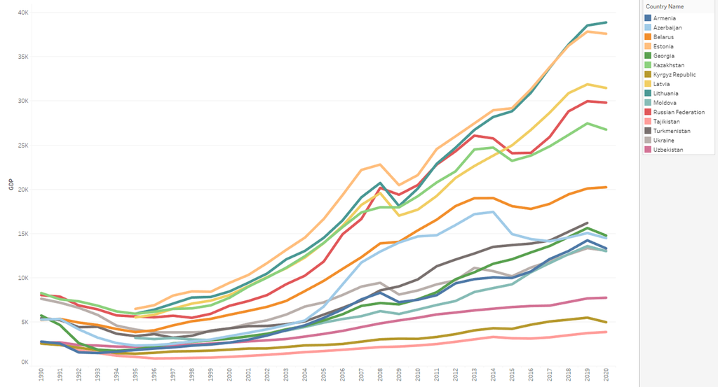

# KSI - korupcijos suvokimo indeksas

[figure not shown]

https://ourworldindata.org/grapher/ti-corruption-perception-index?tab=chart&country=ARM~AZE~BLR~EST~GEO~KAZ~KGZ~LTU~LVA~MDA~RUS~TJK~TKM~UKR~UZB

# Išvados

# Hipotezės

Žmogaus gerovė pasaulyje dažnai matuojama BVP per capita rodikliu, tačiau reikėtų atkreipti dėmesį ir į valstybės valdymo sistemas, demokratija ar diktatūra? Diktatoriniuose rėžimuose aukštas BVP nebūtinai atspindi eilinio žmogaus gerovę, kadangi kapitalas nebūtinai panaudojamas infrastruktūrai, švietimo, sveikatos institucijoms vystyti. Diktatoriniuose rėžimuose didžioji dalis kapitalo yra valdoma oligarchų, kurie dėl stabilumo turtą investuoja demokratiškose valstybėse - perkamas brangus nekilnojamas turtas, jachtos. Transparency.org duomenimis vien tiktai Jungtinėje Karalystėje į nekilnojamą turtą yra investuota 1.5 milijardo svarų 'nešvarių' Rusijos pinigų. https://www.transparency.org.uk/russia-sanctions-UK-latest-news-property-dirty-money-suspect-wealth

Vertinkime tai, kad gyvename demokratijoje, kur galime viešai reikšti savo nuomonę, protestuoti prieš neteisybę be baimės sėsti į kalėjimą ir turėdami galimybę išsirinkti valstybės vadovą kas penkerius metus. Demokratija tai darnus kelias į žmogaus ir valstybės gerovę.

[figure not shown]